# SIM_CM1_F_M0724015

Theresia Wiwid Dwi Suryawati

2026-05-25

# Faktor yang Secara Signifikan Mempengaruhi Total Pendapatan yang Dihasilkan oleh Setiap Kategori Film dalam Database Sakila

# Pendahuluan

Perkembangan teknologi digital telah mengubah industri hiburan, termasuk bisnis rental film. Meskipun layanan streaming kini lebih dominan, data transaksi rental film tetap menarik untuk dianalisis karena dapat memberikan gambaran mengenai perilaku pelanggan dan strategi bisnis yang efektif.

Dalam penelitian ini digunakan database Sakila, yaitu basis data contoh yang mensimulasikan sistem rental film secara realistis. Data yang tersedia mencakup informasi film, kategori, transaksi rental, dan pembayaran pelanggan.

Penelitian ini bertujuan untuk menganalisis faktor-faktor yang mempengaruhi total pendapatan setiap kategori film. Analisis dilakukan menggunakan visualisasi data dan regresi linear berganda untuk mengetahui pengaruh jumlah film, rata-rata harga sewa, dan total rental terhadap pendapatan kategori film.

# Persiapan Data

```r
library(DBI)
library(tidyverse)
```

```r
library(ggplot2)
library(knitr)
library(kableExtra)
library(scales)
library(corrplot)
library(broom)
```

## Koneksi Database MySQL

```r
con <- DBI::dbConnect(odbc::odbc(),
                      Driver = "MySQL ODBC 8.0 ANSI Driver",
                      Server = "127.0.0.1",
                      Database = "Sakila",
                      UID = "root",
                      PWD = "Widwid1234",
                      Port = 3306)
```

## Pendapatan per Kategori Film

```r
query_kategori <- "
SELECT
    c.name                          AS kategori,
    COUNT(DISTINCT f.film_id)       AS jumlah_film,
    ROUND(AVG(f.rental_duration),2) AS rata_durasi_rental,
    ROUND(AVG(f.rental_rate),2)     AS rata_harga_sewa,
    ROUND(AVG(f.length),2)          AS rata_durasi_film,
    COUNT(r.rental_id)              AS total_rental,
    ROUND(SUM(p.amount), 2)         AS total_pendapatan
FROM category        c
JOIN film_category   fc ON c.category_id = fc.category_id
JOIN film            f  ON fc.film_id    = f.film_id
JOIN inventory       i  ON f.film_id     = i.film_id
JOIN rental          r  ON i.inventory_id = r.inventory_id
JOIN payment         p  ON r.rental_id   = p.rental_id
GROUP BY c.name
ORDER BY total_pendapatan DESC;
"

df_kategori <- dbGetQuery(con, query_kategori)
```

## Detail Rental per Film

```r
query_film <- "
SELECT
    f.film_id,
    f.title,
    c.name                       AS kategori,
    f.rental_rate                AS harga_sewa,
    f.rental_duration            AS durasi_sewa,
    f.length                     AS durasi_film,
    COUNT(r.rental_id)           AS total_rental,
    ROUND(SUM(p.amount), 2)      AS total_pendapatan
FROM film            f
JOIN film_category   fc ON f.film_id     = fc.film_id
JOIN category        c  ON fc.category_id = c.category_id
JOIN inventory       i  ON f.film_id     = i.film_id
JOIN rental          r  ON i.inventory_id = r.inventory_id
JOIN payment         p  ON r.rental_id   = p.rental_id
GROUP BY f.film_id, f.title, c.name, f.rental_rate, f.rental_duration, f.length
HAVING total_rental > 0;
"

df_film <- dbGetQuery(con, query_film)

dbDisconnect(con)
```

## Data Cleaning

```r
df_kategori <- df_kategori %>%
  mutate(across(where(is.character) & !matches("kategori"), as.numeric)) %>%
  mutate(kategori = as.factor(kategori))

df_film <- df_film %>%
  mutate(
    harga_sewa       = as.numeric(harga_sewa),
    total_pendapatan = as.numeric(total_pendapatan),
    total_rental     = as.integer(total_rental),
    durasi_film      = as.numeric(durasi_film),
    kategori         = as.factor(kategori)
  ) %>%
  filter(!is.na(total_pendapatan), total_pendapatan > 0)   # hapus nilai kosong

cat(sprintf("Jumlah kategori : %d\n", nrow(df_kategori)))
```

```
## Jumlah kategori : 16
```

```r
cat(sprintf("Jumlah film     : %d\n", nrow(df_film)))
```

```
## Jumlah film     : 958
```

# Deskripsi Data

## Variabel Dataset Kategori

```r
deskripsi_var <- tibble(
  Variabel            = c("kategori", "jumlah_film", "rata_durasi_rental",
                          "rata_harga_sewa", "rata_durasi_film",
                          "total_rental", "total_pendapatan"),
  `Tipe Data`         = c("Factor", "Integer", "Numeric", "Numeric",
                          "Numeric", "Integer", "Numeric"),
  Keterangan          = c(
    "Nama genre/kategori film",
    "Jumlah judul film unik dalam kategori",
    "Rata-rata lama periode sewa yang diizinkan (hari)",
    "Rata-rata tarif sewa per film (USD)",
    "Rata-rata durasi tayang film (menit)",
    "Total jumlah transaksi rental",
    "Total pendapatan dari pembayaran (USD)"
  )
)

kable(deskripsi_var,
      caption = "Deskripsi Variabel Dataset Kategori Film",
      align   = c("l","c","l")) %>%
  kable_styling(bootstrap_options = c("striped","hover","condensed","responsive"),
                full_width         = FALSE,
                font_size          = 13) %>%
  column_spec(1, bold = TRUE, color = "black") %>%
  column_spec(2, color = "black") %>%
  row_spec(0, bold = TRUE, background = "darkblue", color = "white")
```

Deskripsi Variabel Dataset Kategori Film

| Variabel | Tipe Data | Keterangan |
| --- | --- | --- |
| kategori | Factor | Nama genre/kategori film |
| jumlah_film | Integer | Jumlah judul film unik dalam kategori |
| rata_durasi_rental | Numeric | Rata-rata lama periode sewa yang diizinkan (hari) |
| rata_harga_sewa | Numeric | Rata-rata tarif sewa per film (USD) |
| rata_durasi_film | Numeric | Rata-rata durasi tayang film (menit) |
| total_rental | Integer | Total jumlah transaksi rental |
| total_pendapatan | Numeric | Total pendapatan dari pembayaran (USD) |

## Ringkasasn Statistik

```r
ringkasan <- df_kategori %>%
  summarise(
    across(
      c(jumlah_film, rata_harga_sewa, total_rental, total_pendapatan),
      list(
        Min    = ~as.numeric(min(.)),
        Median = ~as.numeric(median(.)),
        Rata2  = ~round(as.numeric(mean(.)), 2),
        Maks   = ~as.numeric(max(.))
      ),
      .names = "{.col}__{.fn}"
    )
  ) %>%
  pivot_longer(
    everything(),
    names_to = c("Variabel", "Statistik"),
    names_sep = "__"
  ) %>%
  pivot_wider(
    names_from = Statistik,
    values_from = value
  )

kable(ringkasan,
      caption = "**Tabel 2.** Statistik Deskriptif Variabel Numerik",
      digits  = 2,
      align   = "lrrrr") %>%
  kable_styling(bootstrap_options = c("striped","hover","condensed","responsive"),
                full_width         = FALSE,
                font_size          = 13) %>%
  row_spec(0, bold = TRUE, background = "darkblue", color = "white")
```

**Tabel 2.** Statistik Deskriptif Variabel Numerik

| Variabel | Min | Median | Rata2 | Maks |
| --- | --- | --- | --- | --- |
| jumlah_film | 51.00 | 59.00 | 59.00 | 73.00 |
| rata_harga_sewa | 2.62 | 3.03 | 2.95 | 3.32 |
| total_rental | 830.00 | 969.00 | 1002.00 | 1179.00 |
| total_pendapatan | 3417.72 | 4276.00 | 4212.91 | 5314.21 |

## Tampilan Data Mentah

```r
kable(df_kategori,
      caption = "**Tabel 3.** Data Pendapatan dan Aktivitas Rental per Kategori Film",
      digits  = 2,
      col.names = c("Kategori","Jml. Film","Rata Dur. Sewa (hr)",
                    "Rata Harga (USD)","Rata Dur. Film (mnt)",
                    "Total Rental","Total Pendapatan (USD)"),
      align   = c("l","c","c","c","c","r","r")) %>%
  kable_styling(bootstrap_options = c("striped","hover","condensed","responsive"),
                full_width         = TRUE,
                font_size          = 12) %>%
  row_spec(0, bold = TRUE, background = "darkblue", color = "white") %>%
  column_spec(7, bold = TRUE, color = "red")
```

**Tabel 3.** Data Pendapatan dan Aktivitas Rental per Kategori Film

| Kategori | Jml. Film | Rata Dur. Sewa (hr) | Rata Harga (USD) | Rata Dur. Film (mnt) | Total Rental | Total Pendapatan (USD) |
| --- | --- | --- | --- | --- | --- | --- |
| Sports | 73 | 4.74 | 3.07 | 128.75 | 1179 | 5314.21 |
| Sci-Fi | 59 | 4.78 | 2.99 | 105.56 | 1101 | 4756.98 |
| Animation | 64 | 4.80 | 2.76 | 108.78 | 1166 | 4656.30 |
| Drama | 61 | 5.06 | 3.18 | 122.60 | 1060 | 4587.39 |
| Comedy | 56 | 4.80 | 3.28 | 111.71 | 941 | 4383.58 |
| Action | 61 | 4.93 | 2.67 | 108.75 | 1112 | 4375.85 |
| New | 60 | 4.50 | 3.09 | 109.05 | 940 | 4351.62 |
| Games | 58 | 5.01 | 3.13 | 128.15 | 969 | 4281.33 |
| Foreign | 67 | 5.12 | 2.95 | 123.12 | 1033 | 4270.67 |
| Family | 67 | 5.16 | 2.70 | 111.33 | 1096 | 4226.07 |
| Documentary | 63 | 4.65 | 2.62 | 110.97 | 1050 | 4217.52 |
| Horror | 53 | 4.92 | 3.10 | 113.32 | 846 | 3722.54 |
| Children | 58 | 5.00 | 2.69 | 111.44 | 945 | 3655.55 |
| Classics | 54 | 4.94 | 2.64 | 113.06 | 939 | 3639.59 |
| Travel | 53 | 5.47 | 3.32 | 117.01 | 837 | 3549.64 |
| Music | 51 | 5.25 | 3.06 | 115.70 | 830 | 3417.72 |

# Visualisasi Data

```r
palet_utama <- c(
  "#1d3557", # navy gelap
  "#457b9d", # muted blue
  "#8ecae6", # soft sky blue
  "#a8dadc", # pastel cyan
  "#2a9d8f", # teal
  "#84a59d", # sage green
  "#52796f", # dark sage
  "#6d597a", # muted purple
  "#b56576", # dusty rose
  "#bc4749", # earthy red
  "#d62828", # deep red
  "#e63946", # primary red
  "#f4a261", # soft orange
  "#dda15e", # muted gold
  "#ffb703", # amber
  "#219ebc"  # cyan blue
)

tema_custom <- theme_minimal(base_size = 12) +
  theme(
    plot.title       = element_text(face = "bold", size = 14, color = "#2c3e50"),
    plot.subtitle    = element_text(size = 11, color = "#7f8c8d"),
    plot.caption     = element_text(size = 9,  color = "#95a5a6", hjust = 0),
    axis.title       = element_text(color = "#2c3e50", size = 11),
    axis.text        = element_text(color = "#2c3e50"),
    panel.grid.major = element_line(color = "#ecf0f1"),
    panel.grid.minor = element_blank(),
    legend.position  = "bottom"
  )
```

## Total Pendapatan per Kategori Film

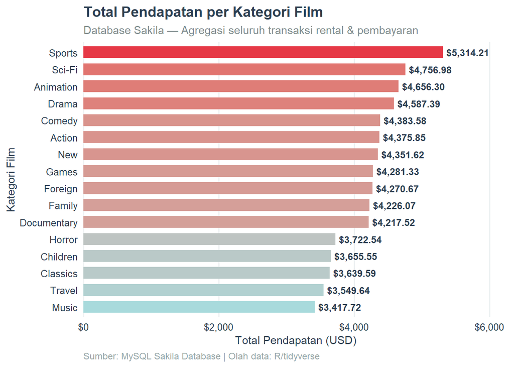

```r
df_kategori_sorted <- df_kategori %>%
  mutate(kategori = fct_reorder(kategori, total_pendapatan))

ggplot(df_kategori_sorted,
       aes(x = total_pendapatan, y = kategori, fill = total_pendapatan)) +
  geom_col(width = 0.7, show.legend = FALSE) +
  geom_text(aes(label = dollar(total_pendapatan, prefix = "$", big.mark = ",")),
            hjust = -0.08, size = 3.3, color = "#2c3e50", fontface = "bold") +
  scale_fill_gradient(low = "#a8dadc", high = "#e63946") +
  scale_x_continuous(
    labels = dollar_format(prefix = "$", big.mark = ","),
    expand = expansion(mult = c(0, 0.18))
  ) +
  labs(
    title    = "Total Pendapatan per Kategori Film",
    subtitle = "Database Sakila — Agregasi seluruh transaksi rental & pembayaran",
    caption  = "Sumber: MySQL Sakila Database | Olah data: R/tidyverse",
    x        = "Total Pendapatan (USD)",
    y        = "Kategori Film"
  ) +
  tema_custom +
  theme(panel.grid.major.y = element_blank())
```

### Interpretasi

Bar chart menunjukkan bahwa kategori Sports menghasilkan total pendapatan tertinggi sebesar sekitar $5.314, diikuti oleh Sci-Fi dan Animation. Hal ini menandakan bahwa kategori tersebut memiliki performa transaksi yang paling baik dibanding kategori lainnya.

Sebaliknya, kategori Music, Travel, dan Classics memiliki total pendapatan terendah, sehingga kontribusinya terhadap keseluruhan pendapatan relatif kecil.

Secara umum, sebagian besar kategori memiliki total pendapatan di kisaran 4.000 USD – 4.700 USD, yang menunjukkan distribusi pendapatan antar kategori cukup merata meskipun terdapat beberapa kategori yang lebih unggul.

## Hubungan Jumlah Rental vs. Total Pendapatan

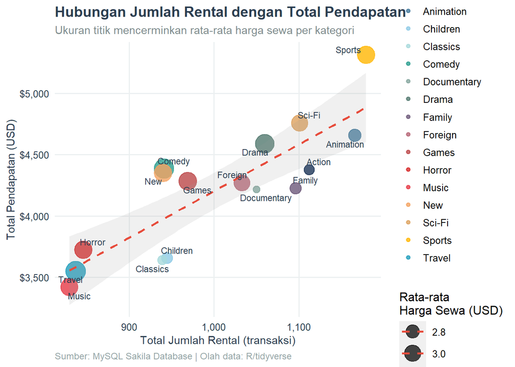

```r
ggplot(df_kategori,
       aes(x = total_rental, y = total_pendapatan,
           color = kategori, size = rata_harga_sewa, label = kategori)) +
  geom_point(alpha = 0.8) +
  geom_smooth(aes(group = 1), method = "lm", se = TRUE,
              color = "#e74c3c", linetype = "dashed", linewidth = 0.9,
              alpha = 0.15) +
  ggrepel::geom_text_repel(size = 3, max.overlaps = 20,
                           color = "#2c3e50", show.legend = FALSE) +
  scale_color_manual(values = palet_utama) +
  scale_x_continuous(labels = comma) +
  scale_y_continuous(labels = dollar_format(prefix = "$")) +
  scale_size_continuous(range = c(3, 9), name = "Rata-rata\nHarga Sewa (USD)") +
  labs(
    title    = "Hubungan Jumlah Rental dengan Total Pendapatan",
    subtitle = "Ukuran titik mencerminkan rata-rata harga sewa per kategori",
    caption  = "Sumber: MySQL Sakila Database | Olah data: R/tidyverse",
    x        = "Total Jumlah Rental (transaksi)",
    y        = "Total Pendapatan (USD)",
    color    = "Kategori"
  ) +
  tema_custom +
  theme(legend.position = "right")
```

### Interpretasi

Scatter plot menunjukkan adanya hubungan positif antara jumlah rental dan total pendapatan. Semakin banyak transaksi rental, maka pendapatan cenderung meningkat.

Kategori Sports memiliki pendapatan tertinggi, sedangkan Music dan Travel memiliki pendapatan terendah. Kategori seperti Sci-Fi, Drama, dan Animation juga menunjukkan performa pendapatan yang tinggi seiring jumlah rental yang besar.

Ukuran titik menunjukkan rata-rata harga sewa, sehingga kategori dengan titik lebih besar memiliki harga sewa rata-rata yang lebih tinggi dan turut memengaruhi total pendapatan.

## Heatmap Korelasi Antar Variabel

```r
df_num <- df_kategori %>%
  select(jumlah_film, rata_durasi_rental, rata_harga_sewa,
         rata_durasi_film, total_rental, total_pendapatan)

mat_cor <- cor(df_num, method = "pearson")
```

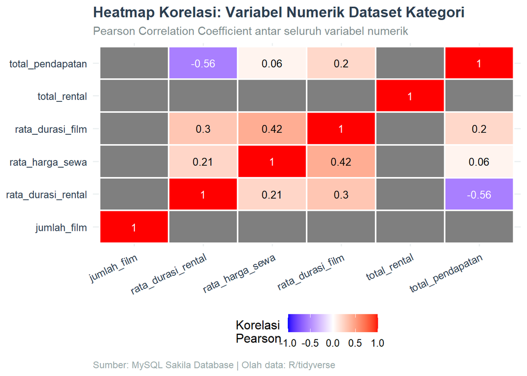

```r
cor_long <- as.data.frame(as.table(mat_cor)) %>%
  rename(Var1 = Var1, Var2 = Var2, Korelasi = Freq)

ggplot(cor_long, aes(x = Var1, y = Var2, fill = Korelasi)) +
  geom_tile(color = "white", linewidth = 0.8) +
  geom_text(aes(label = round(Korelasi, 2)), size = 3.5,
            color = ifelse(abs(as.data.frame(as.table(mat_cor))$Freq) > 0.5,
                           "white", "black")) +
  scale_fill_gradient2(low = "blue", mid = "white", high = "red",
                       midpoint = 0, limit = c(-1,1),
                       name = "Korelasi\nPearson") +
  labs(
    title    = "Heatmap Korelasi: Variabel Numerik Dataset Kategori",
    subtitle = "Pearson Correlation Coefficient antar seluruh variabel numerik",
    caption  = "Sumber: MySQL Sakila Database | Olah data: R/tidyverse",
    x        = NULL, y = NULL
  ) +
  tema_custom +
  theme(axis.text.x = element_text(angle = 25, hjust = 1))
```

### Interpretasi

Heatmap menunjukkan hubungan antar variabel numerik dalam dataset kategori berdasarkan koefisien korelasi Pearson. Nilai korelasi positif menunjukkan hubungan searah, sedangkan nilai negatif menunjukkan hubungan berlawanan arah.

Variabel rata_harga_sewa dan rata_durasi_film memiliki korelasi positif sedang sebesar 0,42, yang berarti semakin lama durasi film maka rata-rata harga sewanya cenderung meningkat. Selain itu, rata_durasi_rental juga memiliki hubungan positif dengan rata_durasi_film sebesar 0,30 dan dengan rata_harga_sewa sebesar 0,21, meskipun hubungan tersebut tergolong lemah.

Sementara itu, total_pendapatan memiliki korelasi negatif cukup kuat dengan rata_durasi_rental sebesar -0,56. Hal ini menunjukkan bahwa semakin lama rata-rata durasi rental, total pendapatan cenderung menurun. Di sisi lain, hubungan antara total_pendapatan dengan rata_harga_sewa (0,06) dan rata_durasi_film (0,20) sangat lemah, sehingga pengaruhnya terhadap pendapatan tidak terlalu signifikan.

# Analisis Data

Analisis regresi linear berganda dilakukan untuk mengestimasi pengaruh simultan dari variabel-variabel operasional (jumlah film, harga sewa, jumlah rental) terhadap total pendapatan per kategori film.

## Model Matematis

Model regresi linear berganda yang digunakan adalah:

$$\hat{Y}_i = \beta_0 + \beta_1 X_{1i} + \beta_2 X_{2i} + \beta_3 X_{3i} +
\varepsilon_i$$

- $\hat{Y}_i$ : Estimasi total pendapatan kategori ke-$i$ (USD)
- $X_{1i}$ : Jumlah film unik dalam kategori ke-$i$
- $X_{2i}$ : Rata-rata harga sewa kategori ke-$i$ (USD)
- $X_{3i}$ : Total jumlah rental kategori ke-$i$
- $\beta_0$ : Intersep
- $\beta_1, \beta_2, \beta_3$ : Koefisien regresi
- $\varepsilon_i$ : Residual / galat

Asumsi dasar model: $\varepsilon_i \sim \mathcal{N}(0, \sigma^2)$, yaitu residual berdistribusi normal dengan rata-rata nol dan varians konstan (homoskedastisitas).

Koefisien determinasi ($R^2$) dihitung sebagai:

$$R^2 = 1 - \frac{SS_{\text{res}}}{SS_{\text{tot}}} = 1 -
\frac{\sum_{i}(Y_i - \hat{Y}_i)^2}{\sum_{i}(Y_i - \bar{Y})^2}$$

```r
df_reg <- df_kategori %>%
  select(
    total_pendapatan,
    jumlah_film,
    rata_harga_sewa,
    total_rental
  ) %>%
  data.frame() %>%
  mutate(
    across(
      everything(),
      ~as.numeric(as.character(.))
    )
  )
```

## Regresi

```r
model_reg <- lm(
  total_pendapatan ~ jumlah_film +
    rata_harga_sewa + total_rental,
  data = df_reg
)

summary(model_reg)
```

```
##
## Call:
## lm(formula = total_pendapatan ~ jumlah_film + rata_harga_sewa +
##     total_rental, data = df_reg)
##
## Residuals:
##     Min      1Q  Median      3Q     Max
## -267.81 -106.11   14.33   98.61  270.80
##
## Coefficients:
##                   Estimate Std. Error t value Pr(>|t|)
## (Intercept)     -3678.3471   802.5898  -4.583 0.000629 ***
## jumlah_film         7.2288    13.1205   0.551 0.591776
## rata_harga_sewa  1037.5071   188.4870   5.504 0.000135 ***
## total_rental        4.3825     0.7277   6.023    6e-05 ***
## ---
## Signif. codes:  0 '***' 0.001 '**' 0.01 '*' 0.05 '.' 0.1 ' ' 1
##
## Residual standard error: 156.7 on 12 degrees of freedom
## Multiple R-squared:  0.9241, Adjusted R-squared:  0.9051
## F-statistic: 48.71 on 3 and 12 DF,  p-value: 5.416e-07
```

```r
tidy(model_reg) %>%
  mutate(
    signifikan = case_when(
      p.value < 0.001 ~ "***",
      p.value < 0.01  ~ "**",
      p.value < 0.05  ~ "*",
      p.value < 0.1   ~ ".",
      TRUE            ~ ""
    )
  ) %>%
  kable(
    caption   = "Hasil Estimasi Koefisien Regresi Linear Berganda",
    digits    = 4,
    col.names = c("Variabel","Koefisien (β)","Std. Error","t-value","p-value","Sig."),
    align     = c("l","r","r","r","r","c")
  ) %>%
  kable_styling(bootstrap_options = c("striped","hover","condensed"),
                full_width = FALSE, font_size = 13) %>%
  row_spec(0, bold = TRUE, background = "darkblue", color = "white") %>%
  footnote(general = "Kode signifikansi: *** p<0.001  ** p<0.01  * p<0.05  . p<0.1")
```

Hasil Estimasi Koefisien Regresi Linear Berganda

| Variabel | Koefisien (β) | Std. Error | t-value | p-value | Sig. |
| --- | --- | --- | --- | --- | --- |
| (Intercept) | -3678.3471 | 802.5898 | -4.5831 | 0.0006 | *** |
| jumlah_film | 7.2288 | 13.1205 | 0.5510 | 0.5918 |  |
| rata_harga_sewa | 1037.5071 | 188.4870 | 5.5044 | 0.0001 | *** |
| total_rental | 4.3825 | 0.7277 | 6.0227 | 0.0001 | *** |

Note:  
Kode signifikansi: *** p<0.001 ** p<0.01 * p<0.05 . p<0.1

## Goodness of Fit

```r
glance_fit <- glance(model_reg)

tibble(
  Metrik  = c("R-squared", "Adjusted R-squared", "F-statistic", "p-value (F)", "AIC"),
  Nilai   = c(
    round(glance_fit$r.squared,      4),
    round(glance_fit$adj.r.squared,  4),
    round(glance_fit$statistic,      3),
    signif(glance_fit$p.value,       3),
    round(glance_fit$AIC,            2)
  )
) %>%
  kable(caption = "Ukuran Kebaikan Model (Goodness of Fit)",
        align   = c("l","r")) %>%
  kable_styling(bootstrap_options = c("striped","hover","condensed"),
                full_width = FALSE, font_size = 13) %>%
  row_spec(0, bold = TRUE, background = "darkblue", color = "white")
```

Ukuran Kebaikan Model (Goodness of Fit)

| Metrik | Nilai |
| --- | --- |
| R-squared | 9.2410e-01 |
| Adjusted R-squared | 9.0510e-01 |
| F-statistic | 4.8709e+01 |
| p-value (F) | 5.0000e-07 |
| AIC | 2.1253e+02 |

## Plot Diagnostik Model

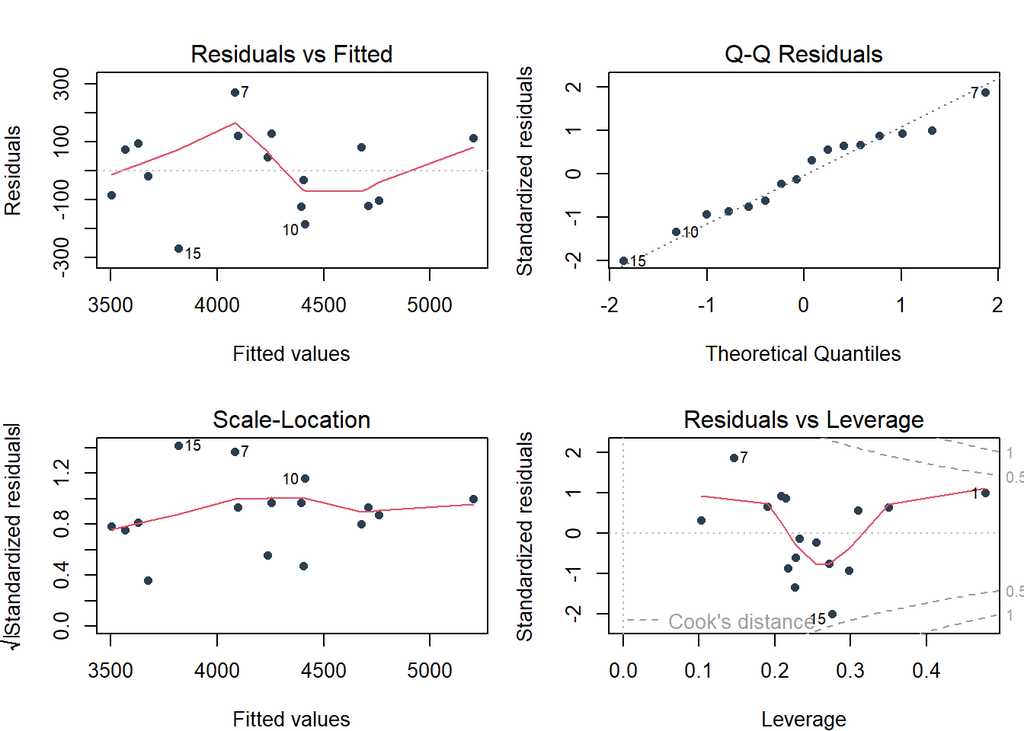

```r
par(mfrow = c(2, 2), mar = c(4, 4, 3, 1))
plot(model_reg, col = "#2c3e50", pch = 16, cex = 0.9)
```

```r
par(mfrow = c(1, 1))
```

## Interpretasi Hasil Regresi

Berdasarkan output model:

- Koefisien total_rental sebesar 4,383 menunjukkan bahwa setiap penambahan satu transaksi rental diasosiasikan dengan peningkatan total pendapatan sekitar 4,38 USD, dengan asumsi variabel lain konstan. Variabel ini signifikan secara statistik (p < 0,001), sehingga menjadi salah satu prediktor utama pendapatan.
- Koefisien rata_harga_sewa sebesar 1037,507 menunjukkan bahwa kenaikan rata-rata harga sewa berkaitan dengan peningkatan total pendapatan. Variabel ini juga signifikan secara statistik (p < 0,001), sehingga harga sewa memiliki kontribusi penting terhadap pendapatan.
- Variabel jumlah_film memiliki koefisien positif sebesar 7,229, namun tidak signifikan secara statistik (p = 0,5918). Hal ini menunjukkan bahwa jumlah film belum terbukti memiliki pengaruh nyata terhadap total pendapatan pada model ini.
- Nilai Adjusted R² sebesar 0,905 menunjukkan bahwa sekitar 90,5% variasi total pendapatan dapat dijelaskan oleh variabel jumlah_film, rata_harga_sewa, dan total_rental. Ini menandakan model memiliki kemampuan penjelasan yang sangat baik.
- Uji simultan melalui F-statistic menghasilkan p-value < 0,001, sehingga model regresi secara keseluruhan signifikan dalam menjelaskan total pendapatan.
- Plot diagnostik menunjukkan bahwa residual cenderung menyebar secara acak dan distribusinya relatif mendekati normal. Tidak terlihat pelanggaran asumsi yang serius, meskipun terdapat beberapa observasi dengan residual cukup besar.

# Pembahasan

## Makna Hasil bagi Bisnis Rental Film

1. Volume transaksi sebagai penggerak utama pendapatan Variabel total_rental terbukti menjadi faktor yang paling konsisten memengaruhi pendapatan. Semakin tinggi jumlah transaksi rental, semakin besar pendapatan yang diperoleh. Hal ini menunjukkan bahwa strategi peningkatan frekuensi rental, seperti promosi atau program loyalitas, berpotensi meningkatkan pendapatan secara signifikan.
2. Harga sewa berpengaruh terhadap peningkatan pendapatan Variabel rata_harga_sewa juga memiliki pengaruh positif dan signifikan terhadap pendapatan. Kategori dengan harga sewa lebih tinggi cenderung menghasilkan pendapatan lebih besar, terutama jika tetap didukung volume rental yang tinggi.
3. Jumlah film bukan faktor utama Meskipun jumlah film memiliki koefisien positif, pengaruhnya tidak signifikan secara statistik. Hal ini menunjukkan bahwa banyaknya judul film dalam kategori belum tentu meningkatkan pendapatan apabila tidak diikuti tingginya transaksi rental atau harga sewa yang optimal.
4. Dominasi kategori tertentu Kategori Sports, Sci-Fi, dan Animation memiliki total pendapatan tertinggi. Hal ini menunjukkan bahwa kategori tersebut memiliki kombinasi permintaan dan performa transaksi yang lebih baik dibanding kategori lainnya.

# Kesimpulan

Berdasarkan analisis data Sakila menggunakan R, dapat disimpulkan:

1. Total jumlah rental merupakan faktor yang paling berpengaruh terhadap pendapatan per kategori, dibuktikan melalui hubungan positif pada scatter plot serta koefisien regresi yang signifikan secara statistik.
2. Rata-rata harga sewa juga berkontribusi positif dan signifikan terhadap peningkatan pendapatan, sehingga strategi penetapan harga memiliki peran penting dalam memaksimalkan nilai transaksi.
3. Kategori Sports, Sci-Fi, dan Animation menjadi kategori dengan performa terbaik karena menghasilkan total pendapatan tertinggi dibanding kategori lainnya.
4. Model regresi linear berganda memiliki kemampuan penjelasan yang sangat baik dengan nilai Adjusted R² sebesar 0,905, yang menunjukkan bahwa sebagian besar variasi total pendapatan dapat dijelaskan oleh variabel dalam model. Namun, variabel jumlah_film tidak terbukti signifikan secara statistik terhadap total pendapatan.